# Project 1: Wrangling, Exploration, Visualization

#### Wrangling

```r
pwt1 <- pwt %>% filter(year >= 2000) %>% mutate(gdp_cap = rgdpna/population) %>%
    arrange(-desc(country), -desc(year))  # gdp_cap to compare the rates at which gdp and pop are changing
pwt1 %>% group_by(country) %>% summarise(mean = mean(gdp_cap)) %>%
    arrange(desc(mean))  # mean gdp per capita by country (good measure of standard of living)
```

```
## # A tibble: 20 x 2
##    country          mean
##    <chr>           <dbl>
##  1 Switzerland    0.0588
##  2 Ireland        0.0522
##  3 Australia      0.0449
##  4 Denmark        0.0448
##  5 Netherlands    0.0437
##  6 Canada         0.0417
##  7 Germany        0.0410
##  8 Sweden         0.0409
##  9 Austria        0.0406
## 10 Iceland        0.0387
## 11 Finland        0.0376
## 12 Belgium        0.0376
## 13 Japan          0.0365
## 14 France         0.0363
## 15 Italy          0.0359
## 16 United Kingdom 0.0355
## 17 Spain          0.0315
## 18 Greece         0.0250
## 19 Portugal       0.0249
## 20 Chile          0.0184
```

```r
pwt1 %>% group_by(country) %>% summarise(mean = mean(hc)) %>%
    slice_max(mean)  # country with highest mean human capital (UK)
```

```
## # A tibble: 1 x 2
##   country         mean
##   <chr>          <dbl>
## 1 United Kingdom  3.66
```

```r
pwt1 %>% group_by(country) %>% summarise(mean = mean(hc)) %>%
    slice_min(mean)  # country with lowest mean human capital (Portugal)
```

```
## # A tibble: 1 x 2
##   country   mean
##   <chr>    <dbl>
## 1 Portugal  2.33
```

```r
pwt1 %>% group_by(country) %>% summarise(mean = mean(rgdpna)) %>%
    slice_max(mean)  # country with highest mean rgdpna (Japan)
```

```
## # A tibble: 1 x 2
##   country     mean
##   <chr>      <dbl>
## 1 Japan   4658718.
```

```r
pwt1 %>% group_by(country) %>% summarise(mean = mean(rgdpna)) %>%
    slice_min(mean)  # country with lowest mean rgdpna (Iceland)
```

```
## # A tibble: 1 x 2
##   country   mean
##   <chr>    <dbl>
## 1 Iceland 12079.
```

```r
pwt1 %>% group_by(country) %>% summarise(sd = sd(population)) %>%
    slice_max(sd)  # country with most population volatility
```

```
## # A tibble: 1 x 2
##   country              sd
##   <chr>             <dbl>
## 1 United Kingdom 2348507.
```

```r
pwt1 %>% group_by(year) %>% summarise(min(labsh), max(labsh))  # checking min and max labsh for each year to identify trends (decreasing min, max stays about same)
```

```
## # A tibble: 18 x 3
##     year `min(labsh)` `max(labsh)`
##    <dbl>        <dbl>        <dbl>
##  1  2000        0.480        0.657
##  2  2001        0.469        0.668
##  3  2002        0.440        0.685
##  4  2003        0.449        0.676
##  5  2004        0.457        0.659
##  6  2005        0.431        0.671
##  7  2006        0.385        0.690
##  8  2007        0.384        0.683
##  9  2008        0.431        0.637
## 10  2009        0.440        0.673
## 11  2010        0.440        0.651
## 12  2011        0.440        0.640
## 13  2012        0.440        0.651
## 14  2013        0.440        0.650
## 15  2014        0.432        0.644
## 16  2015        0.331        0.670
## 17  2016        0.339        0.662
## 18  2017        0.329        0.651
```

```r
pwt1 %>% group_by(country) %>% summarise(cor(rgdpna, hc)) %>%
    kable()  # correlation between rgdp and hc by country
```

| country | cor(rgdpna, hc) |
| --- | --- |
| Australia | -0.2847576 |
| Austria | 0.9757997 |
| Belgium | 0.9736419 |
| Canada | 0.9713997 |
| Chile | 0.9944111 |
| Denmark | 0.9024482 |
| Finland | 0.7920383 |
| France | 0.9679500 |
| Germany | 0.8999625 |
| Greece | -0.4094194 |
| Iceland | 0.9245612 |
| Ireland | 0.8777070 |
| Italy | -0.2324638 |
| Japan | 0.8859597 |
| Netherlands | 0.9403890 |
| Portugal | -0.2684151 |
| Spain | 0.7417498 |
| Sweden | 0.9642855 |
| Switzerland | 0.9877399 |
| United Kingdom | 0.9336096 |

```r
pwt1 %>% summarise_all(function(x) sum(is.na(x)))  # there are no NAs present in the dataset
```

```
## # A tibble: 1 x 7
##   country  year    hc rgdpna labsh population gdp_cap
##     <int> <int> <int>  <int> <int>      <int>   <int>
## 1       0     0     0      0     0          0       0
```

```r
unique(pwt1$country) %>% str_detect(pattern = "^[S]") %>% sum()  # 3 countries have names beginning with 'S.'
```

```
## [1] 3
```

```r
str
```

[output not shown]

```r
pwt1 %>% group_by(year) %>% summarise(n())  #18 diff years
```

```
## # A tibble: 18 x 2
##     year `n()`
##    <dbl> <int>
##  1  2000    20
##  2  2001    20
##  3  2002    20
##  4  2003    20
##  5  2004    20
##  6  2005    20
##  7  2006    20
##  8  2007    20
##  9  2008    20
## 10  2009    20
## 11  2010    20
## 12  2011    20
## 13  2012    20
## 14  2013    20
## 15  2014    20
## 16  2015    20
## 17  2016    20
## 18  2017    20
```

```r
pwt1 %>% group_by(country) %>% summarise(n())  # 20 diff countries
```

```
## # A tibble: 20 x 2
##    country        `n()`
##    <chr>          <int>
##  1 Australia         18
##  2 Austria           18
##  3 Belgium           18
##  4 Canada            18
##  5 Chile             18
##  6 Denmark           18
##  7 Finland           18
##  8 France            18
##  9 Germany           18
## 10 Greece            18
## 11 Iceland           18
## 12 Ireland           18
## 13 Italy             18
## 14 Japan             18
## 15 Netherlands       18
## 16 Portugal          18
## 17 Spain             18
## 18 Sweden            18
## 19 Switzerland       18
## 20 United Kingdom    18
```

```r
pwt2 <- pwt1 %>% group_by(country) %>% summarise(sd = sd(population)) %>%
    pivot_wider(names_from = country, values_from = sd)
pivot_longer(pwt2, cols = c("Australia":"United Kingdom"), names_to = "country")
```

```
## # A tibble: 20 x 2
##    country           value
##    <chr>             <dbl>
##  1 Australia      1741161.
##  2 Austria         230110.
##  3 Belgium         393867.
##  4 Canada         1861434.
##  5 Chile           879690.
##  6 Denmark         131834.
##  7 Finland         113959.
##  8 France         1959221.
##  9 Germany         777610.
## 10 Greece          118029.
## 11 Iceland          18528.
## 12 Ireland         327573.
## 13 Italy          1367476.
## 14 Japan           427203.
## 15 Netherlands     348097.
## 16 Portugal         96739.
## 17 Spain          2252910.
## 18 Sweden          374761.
## 19 Switzerland     413698.
## 20 United Kingdom 2348507.
```

```r
pwt1 %>% group_by(year) %>% summarise(mean(labsh))  # change in labor share among 20 'rich' countries from 2000-2017
```

```
## # A tibble: 18 x 2
##     year `mean(labsh)`
##    <dbl>         <dbl>
##  1  2000         0.593
##  2  2001         0.593
##  3  2002         0.593
##  4  2003         0.593
##  5  2004         0.584
##  6  2005         0.583
##  7  2006         0.579
##  8  2007         0.576
##  9  2008         0.578
## 10  2009         0.589
## 11  2010         0.580
## 12  2011         0.579
## 13  2012         0.580
## 14  2013         0.579
## 15  2014         0.576
## 16  2015         0.569
## 17  2016         0.569
## 18  2017         0.567
```

All data is already tidied, including summarized data, so I untidied the standard deviations of populations by country using pivot_wider, then tidied the data by using pivot_longer at the end of this chunk.

For my analyses I mostly grouped the summaries by country because the main goal of my analysis was to identify the countries that were better than others in certain economic categories since 2000. I summarized the mean gdp per capita, a good measure of standard of living, which helped me identify that Switzerland seemed to have the highest standard of living. Human capital essentially index measures how economically and professionally productive a country’s population is. From my summary, the United Kingdom had the greatest mean human capital index, thus its people were the most economically and professionally productive. Real gdp essentially indicates how much production a country has or how much goods and services it provides. This is a good measure of the overall health of an economy. from my summary, Japan seems to have the healthiest economy while Iceland has the least healthy economy of the countries listed. Also, among most countries in the analysis, there seemed to be strong correlation between real gdp and human capital index, which was expected.

I also used string_detect and regex to figure out that 3 countries have names beginning with the letter “S”

#### Visualizing

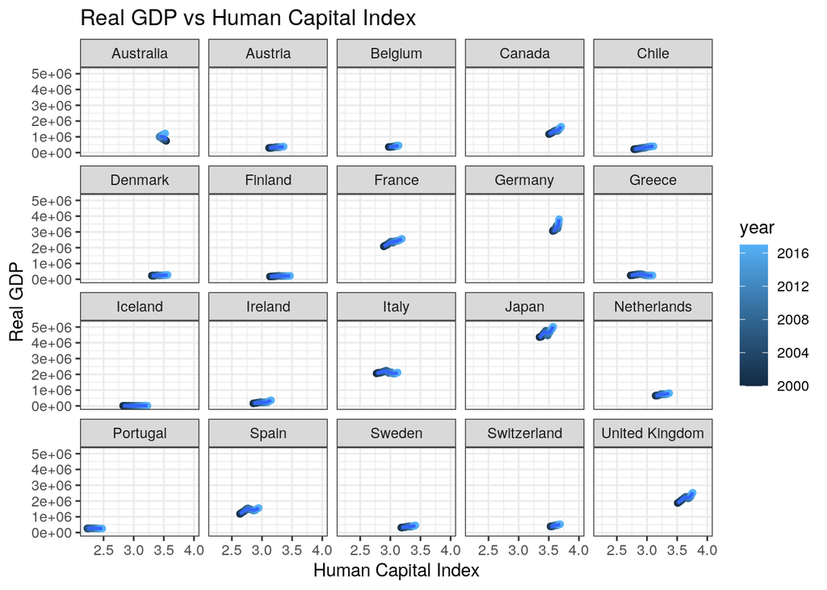

```r
ggplot(pwt1, aes(hc, rgdpna)) + geom_point(aes(color = year)) +
    geom_smooth() + facet_wrap(country ~ .) + xlab("Human Capital Index") +
    ylab("Real GDP") + ggtitle("Real GDP vs Human Capital Index") +
    xlim(2.2, 4) + theme_bw()
```

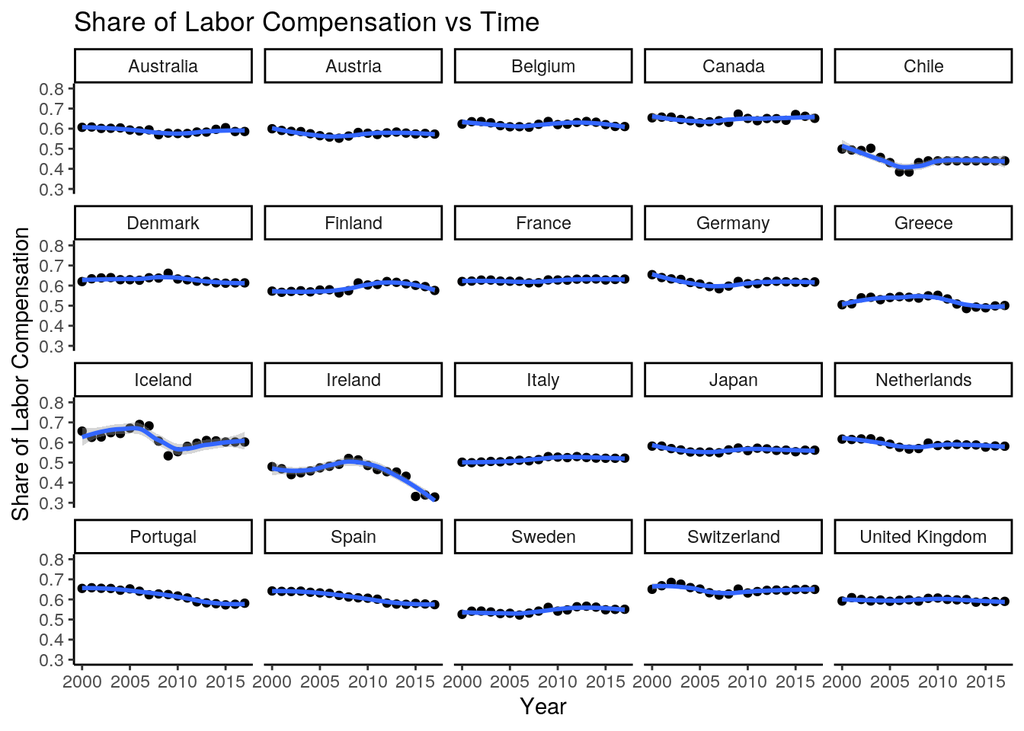

```r
ggplot(pwt1, aes(year, labsh)) + geom_point(aes(y = labsh)) +
    facet_wrap(country ~ .) + geom_smooth() + xlab("Year") +
    ylab("Share of Labor Compensation") + ggtitle("Share of Labor Compensation vs Time") +
    theme_classic() + ylim(0.3, 0.8)
```

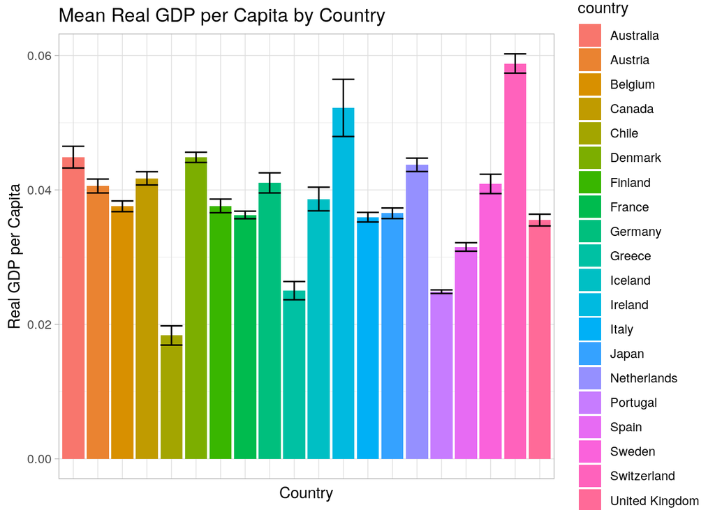

```r
ggplot(pwt1, aes(x = country, y = gdp_cap)) + geom_bar(stat = "summary",
    fun = mean, aes(fill = country)) + geom_errorbar(stat = "summary",
    fun.data = mean_cl_normal) + theme_light() + theme(axis.text.x = element_blank(),
    axis.ticks.x = element_blank()) + xlab("Country") + ylab("Real GDP per Capita") +
    ggtitle("Mean Real GDP per Capita by Country")
```

#### Concluding Remarks

My expectations were partially met. I correctly expected real gdp to grow as human capital index increases; however, the share of labor compensation stayed fairly stable throughout the years when I actually expected it to decrease as time passed.